# 607 Project 2 Food

Lu Beyer

# Overview

```r
library(tidyverse)
x <- read.csv("food_coded.csv")
```

I’m interested to see if either gender seems to perceive themselves are more overweight or more fit, and if that perception shows any correlation between how rewarding life feels, the students GPA, the frequency of exercise, etc., so I wanted to narrow down the data to more easily look at these variables.

```r
y <- x %>%
  select(GPA, grade_level, Gender, healthy_feeling, self_perception_weight, life_rewarding, income, employment, exercise)

         # comfort_food_reasons_coded, cook, cuisine, diet_current_coded, eating_out, fruit_day,  veggies_day, vitamins, ideal_diet_coded, nutritional_check, on_off_campus, parents_cook, pay_meal_out, sports, fav_food, fav_cuisine_coded, ethnic_food, indian_food, italian_food, greek_food,persian_food, thai_food, weight, father_education, mother_education,
```

I didn’t want to rely on the codebook in order to read my data, so I decided to mutate my data so it is more easily read.

```r
z <-  y %>%
  # mutate(weight = as.numeric(gsub("^[0-9]","",weight))) %>%
  mutate(GPA = as.numeric(gsub("[^0-9.]", "", GPA))) %>%
  mutate(grade_level = as.character(gsub("1", "Freshman", grade_level))) %>%
  mutate(grade_level = as.character(gsub("2", "Sophomore", grade_level))) %>%
  mutate(grade_level = as.character(gsub("3", "Junior", grade_level))) %>%
  mutate(grade_level = as.character(gsub("4", "Senior", grade_level))) %>%
  mutate(Gender = as.character(gsub("1", "Female", Gender))) %>%
  mutate(Gender = as.character(gsub("2", "Male", Gender))) %>%
  mutate(self_perception_weight = as.numeric(gsub("[^0-9]", "", self_perception_weight))) %>%
  mutate(self_perception_weight = as.character(gsub("6", "i dont think myself in these terms", self_perception_weight))) %>%
  mutate(self_perception_weight = as.character(gsub("5", "overweight", self_perception_weight))) %>%
  mutate(self_perception_weight = as.character(gsub("4", "slightly overweight", self_perception_weight))) %>%
  mutate(self_perception_weight = as.character(gsub("3", "just right", self_perception_weight))) %>%
  mutate(self_perception_weight = as.character(gsub("2", "very fit", self_perception_weight))) %>%
  mutate(self_perception_weight = as.character(gsub("1", "slim", self_perception_weight))) %>%
  mutate(income = as.character(gsub("^1$", "less than $15,000", income))) %>%
  mutate(income = as.character(gsub("^2$", "$15,001 to $30,000", income))) %>%
  mutate(income = as.character(gsub("^3$", "$30,001 to $50,000", income))) %>%
  mutate(income = as.character(gsub("^4$", "$50,001 to $70,000", income))) %>%
  mutate(income = as.character(gsub("^5$", "$70,001 to $100,000", income))) %>%
  mutate(income = as.character(gsub("^6$", "higher than $100,000", income))) %>%
  mutate(life_rewarding = as.numeric(gsub("[^0-9]", "", life_rewarding))) %>%
  mutate(employment = as.numeric(gsub("[^0-9]", "", employment))) %>%
  mutate(employment = as.character(gsub("1", "yes full time", employment))) %>%
  mutate(employment = as.character(gsub("2", "yes part time", employment))) %>%
  mutate(employment = as.character(gsub("3", "no", employment))) %>%
  mutate(employment = as.character(gsub("4", "other", employment))) %>%
  mutate(exercise = as.numeric(gsub("[^0-9]", "", exercise))) %>%
  mutate(exercise = as.character(gsub("1", "Everyday", exercise))) %>%
  mutate(exercise = as.character(gsub("2", "Twice or three times per week", exercise))) %>%
  mutate(exercise = as.character(gsub("3", "Once a week", exercise))) %>%
  mutate(exercise = as.character(gsub("4", "Sometimes", exercise))) %>%
  mutate(exercise = as.character(gsub("5", "Never", exercise))) %>%
  mutate(life_rewarding_bin = cut(life_rewarding, breaks = c(0,2.5,5,7.5,10), labels = c("0-2.5", "2.5 - 5", "5-7.5", "7.5-10"))) %>%
    mutate(GPA_bin = cut(GPA, breaks = c(2, 2.5, 3, 3.5, 4), labels = c("2-2.5", "2.5-3", "3-3.5", "3.5-4")))
```

I wanted to create a visualization to show the self perception of weight between males and females to more easily see how that data is split.

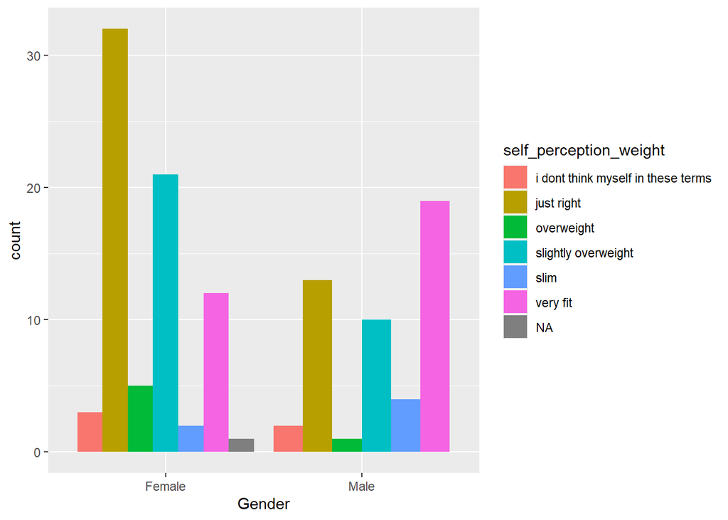

```r
ggplot(data = z, aes(x = Gender, fill = self_perception_weight)) +
  geom_bar(position = "dodge")
```

Seeing this data side by side, I wanted to see how the percentages of each category by gender to see how those numbers differed.

```r
men <- z %>%
  filter(Gender == "Male") %>%
  group_by(self_perception_weight) %>%
  summarise(count = n()) %>%
  mutate(percentage = (count / sum(count))*100)
```

```r
women <- z %>%
  filter(Gender == "Female") %>%
   group_by(self_perception_weight) %>%
  summarise(count = n()) %>%
  mutate(percentage = (count / sum(count))*100)
```

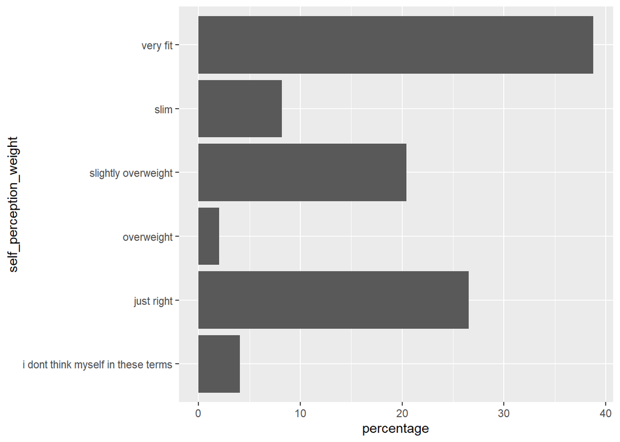

```r
ggplot(data = men, aes(x = percentage , y = self_perception_weight)) +
  geom_bar(stat = "identity")
```

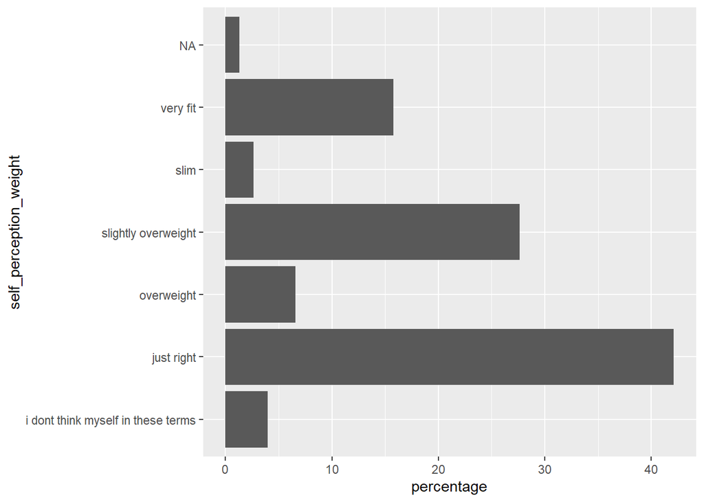

```r
ggplot(data = women, aes(x = percentage , y = self_perception_weight)) +
  geom_bar(stat = "identity")
```

I also wanted to see how males and females viewed how rewarding their lives are.

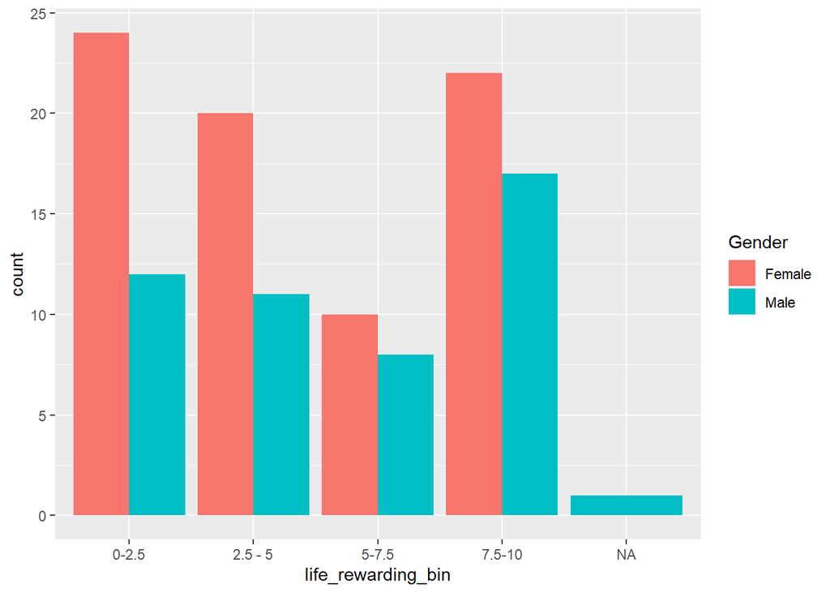

```r
ggplot(data = z, aes(x = life_rewarding_bin, fill = Gender)) +
  geom_bar(position = "dodge")
```

I then wanted to see how a students GPA compares to how rewarding they say their life feels. I oranized their GPA and their ratings for how rewarding their lives are into bins to consolidate the data.

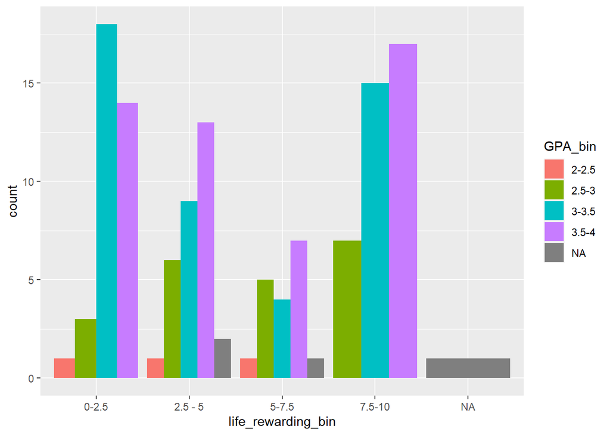

```r
ggplot(data = z, aes(x = life_rewarding_bin, fill = GPA_bin)) +
  geom_bar(position = "dodge")
```

I created visuals to compare reported income and GPA of the surveyed students.

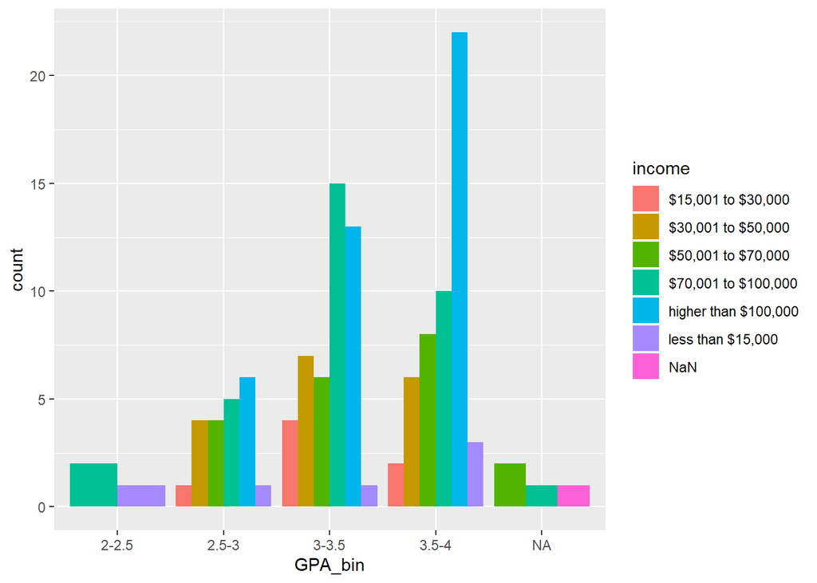

```r
ggplot(data = z, aes(x = GPA_bin, fill = income)) +
  geom_bar(position = "dodge")
```

I wanted to compare the reported income against the gender of the surveyed students.

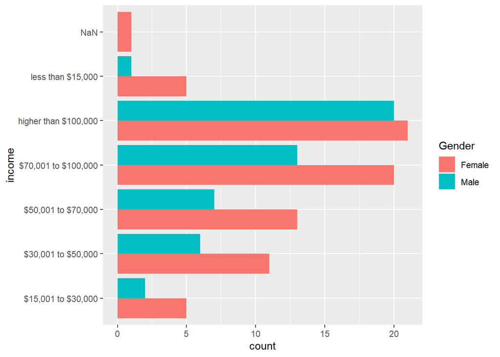

```r
ggplot(data = z, aes(x = income, fill = Gender)) +
  geom_bar(position = "dodge") + coord_flip()
```

I felt that, in general, the counts for females were higher than males so I wanted to see how many males vs females were surveyed.

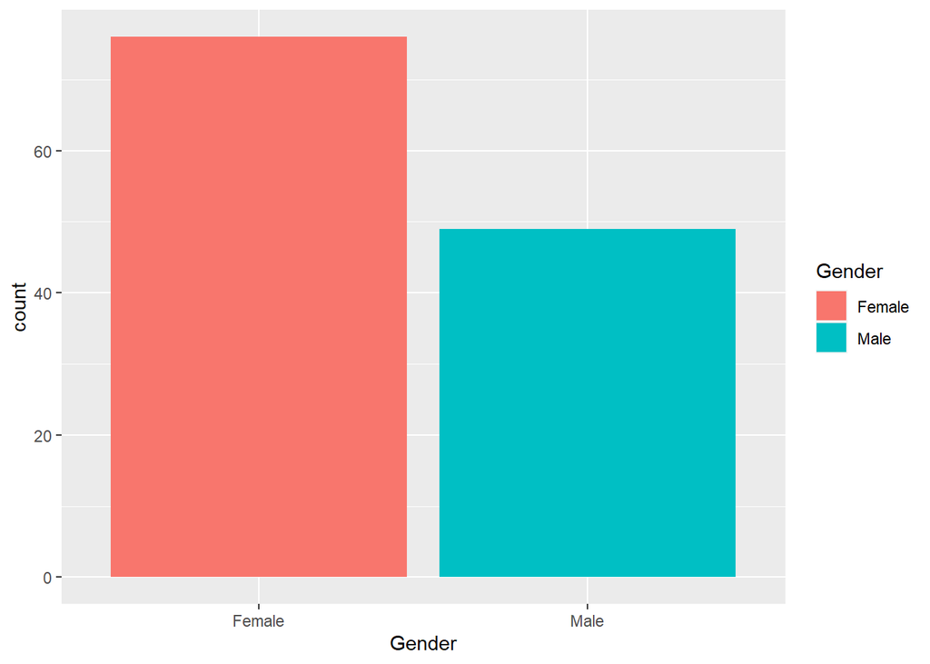

```r
ggplot(data = z, aes(x = Gender, fill = Gender)) +
  geom_bar()
```

```r
table(z$Gender)
```

```
##
## Female   Male
##     76     49
```

Finally, I wanted to look at the counts of students surveyed across their grade level.

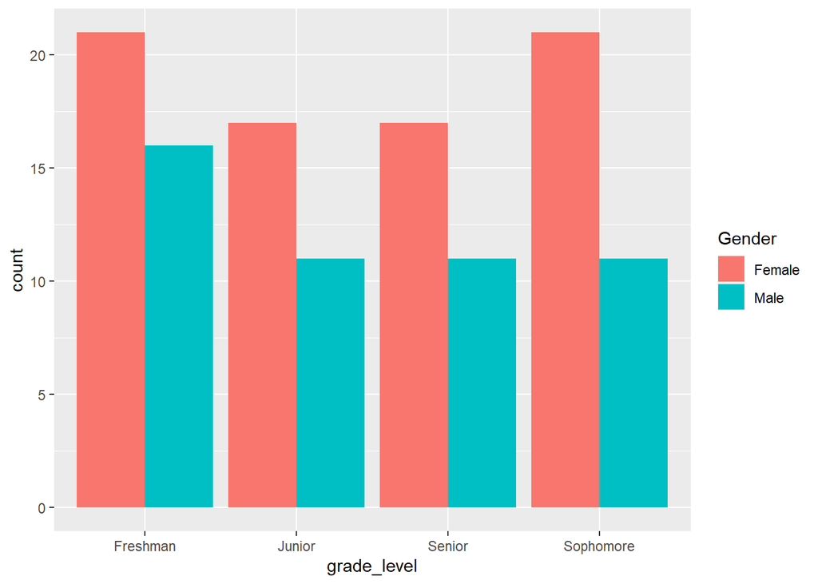

```r
ggplot(data = z, aes(x = grade_level, fill = Gender)) +
  geom_bar(position = "dodge")
```

# Conclusion

Comparing the students perception of how rewarding their life was and their GPA, my assumption was that the more rewarding the students life felt, the higher their GPA would be. I assumed students who felt their lives were more rewarding would have more capacity for school and likely be able to do better. That largely wasn’t the case; students who felt their lives were the least rewarding based on the given scale had the highest count of students with a GPA of 3-3.5 and the second highest count of students with a GPA of 3.5-4. Students with the highest rating of life fulfillment had no counts of students with a GPA of 2-2.5, but the highest count of students with a 2.5-3. None of the data I chose to analyze supported any of my initial thoughts before organizing this data, but after organizing, I didn’t really gain any clarity either.

The most shocking part of this data is the amount of college students claiming they make more than $100,000. This did make me somewhat skeptical about the data set as a whole, but maybe college students make more money than I was aware of.